# Исследование закономерностей, определяющих успешность игр

# Содержание

Интернет-магазин «Стримчик» продаёт по всему миру компьютерные игры. Из открытых источников доступны исторические данные о продажах игр (в годы выпуска), оценки пользователей и экспертов, жанры и платформы (например, Xbox или PlayStation).

Требуется выявить определяющие успешность игры закономерности. Это позволит сделать ставку на потенциально популярный продукт и спланировать рекламные кампании для различных платформ.

Имеются данные до 2016 года. В предположении, что сейчас декабрь 2016 г., планируется кампания на 2017-й (основная цель - отработка принципов работы с данными).

В наборе данных попадается аббревиатура *ESRB (Entertainment Software Rating Board)* — это ассоциация, определяющая возрастной рейтинг компьютерных игр. ESRB оценивает игровой контент и присваивает ему подходящую возрастную категорию, например, «Для взрослых», «Для детей младшего возраста» или «Для подростков».

*В ходе исследования предполагается:*

- изучить данные;
- подготовить данные к анализу;
- провести исследовательский анализ данных;
- составить типичный портрет пользователя каждого региона;
- проверить статистические гипотезы:
  - средние пользовательские рейтинги платформ Xbox One и PC - одинаковые
  - средние пользовательские рейтинги жанров Action и Sports - разные

*Данные хранятся в файле:* /datasets/games.csv

*Примечание:* данные за 2016 год могут быть неполными.

## Определение функций проекта

### Импорт библиотек

```python
import pandas as pd
import numpy as np
import math as mt
import matplotlib.pyplot as plt
from scipy import stats as st
import seaborn as sns
```

### Функции обзора данных

```python
# определение функции обзора данных
# =================================
# на вход подаётся датафрейм df
# на выходе:
#     - 10 случайных строк df
#     - информация df.info()
#     - количество явных дубликатов в строках df
#     - процент пропусков данных в столбцах df
def data_observe(df):
    row_num = 5    # количество отображаемых строк таблицы

    print('Произвольные строки таблицы:')
    print('============================')
    if len(df) >= row_num:
        display(df.sample(row_num))
    else:
        display(df)

    print('\nИнформация о таблице:')
    print('=====================')
    df.info()

    print('\nКоличество явных дубликатов в таблице:')
    print('======================================')
    print(df.duplicated().sum())

    print('\nПроцент пропусков в столбцах:')
    print('=============================')
    display(pd.DataFrame(
                round((df.isna().mean()*100),2), columns=['NaNs, %'])
                .sort_values(by='NaNs, %', ascending=False
            )
        .style.format('{:.2f}')
        .background_gradient('coolwarm')
    )
```

```python
# определение функции открытия файла
# ==================================
# на вход подаётся:
#     file_name - имя файла
# на выходе - датафрейм с загруженными данными
def open_file(file_name):
    try:
        df = pd.read_csv('/datasets/' + file_name)
    except:
        df = pd.read_csv(file_name)

    return df
```

### Функции предобработки данных

```python
# определение функции вывода уникальных значений
# набора столбцов датафрейма
# ==============================================
# на вход подаётся:
#     df - датафрейм
#     columns - список столбцов
# функция выводит списки уникальных значений для
# каждого столбца из columns
def show_unique_values(df, columns):
    for col in columns:
        print(f'Уникальные значения столбца {col}:\n',
             df[col].sort_values().unique(), '\n')
```

### Функции построения графиков и диаграмм

```python
# определение функции построения линейного графика
# ================================================
def build_line_plot(df, x_col, y_col, hue=None, title=None, x_label=None,
                    y_label=None, ax=None, figsize=(10, 10)):
    ax = ax
    if ax == None:
        fig, ax = plt.subplots(figsize=figsize)

    sns.lineplot(data=df, x=x_col, y=y_col, hue=hue, ax=ax)
    plt.grid(True)
    if title != None:
        plt.title(title)
    if x_label != None:
        plt.xlabel(x_label)
    if y_label != None:
        plt.ylabel(y_label)
    plt.show()
```

```python
# определение функции построения диаграммы размаха
# ================================================
def build_box_plot(df, x_col, y_col, title=None, x_label=None, y_label=None,
                   y_lim=None, ax=None, figsize=(15, 10)):

    ax = ax
    if ax == None:
        fig, ax = plt.subplots(figsize=figsize)

    sns.boxplot(x=x_col, y=y_col, data=df)
    plt.grid(True)
    if title != None:
        plt.title(title)
    if x_label != None:
        plt.xlabel(x_label)
    if y_label != None:
        plt.ylabel(y_label)
    if y_lim != None:
        plt.ylim(y_lim)
    plt.show()
```

```python
# определение функции построения диаграммы рассеяния
# ==================================================
def build_scatter_plot(df, x_col, y_col, hue=None, title=None, palette=None,
                       x_label=None, y_label=None, y_lim=None, ax=None,
                       alpha=None, figsize=(7, 7)):

    ax = ax
    if ax == None:
        fig, ax = plt.subplots(figsize=figsize)

    sns.scatterplot(x=x_col, y=y_col,
                    hue=hue,
                    palette=palette,
                    sizes=(1, 8), linewidth=0,
                    data=df,
                    alpha=alpha,
                    ax=ax)
    plt.grid(True)
    if title != None:
        plt.title(title)
    if x_label != None:
        plt.xlabel(x_label)
    if y_label != None:
        plt.ylabel(y_label)
    if y_lim != None:
        plt.ylim(y_lim)
    plt.show()
```

```python
# определение функции построения столбчатой диаграммы
# ===================================================
def build_bar_plot(df, x_col, y_col, hue=None, title=None, x_label=None,
                    y_label=None, ax=None, figsize=(10, 10)):
    ax = ax
    if ax == None:
        fig, ax = plt.subplots(figsize=figsize)

    sns.barplot(data=df, x=x_col, y=y_col, hue=hue, ax=ax)
    plt.grid(True)
    if title != None:
        plt.title(title)
    if x_label != None:
        plt.xlabel(x_label)
    if y_label != None:
        plt.ylabel(y_label)
    plt.show()
```

### Функции EDA

```python
# определение функции выбора перспективных платформ в диапазоне лет
# =================================================================
# на вход подаётся:
#     df - датафрейм
#     first_year - начало диапазона
#     last_year - конец диапазона
# на выходе - список платформ по убыванию суммарных продаж
def get_top_platforms(df, first_year, last_year):
    date_range = range(first_year, last_year+1)
    return (
        games_actual[games_actual['year_of_release'].isin([x for x in date_range])]
        .groupby(by='platform')['total_sales'].sum().sort_values(ascending=False)
    )
```

```python
# определение функции описания профиля пользователей региона
# ==========================================================
# на вход подаётся:
#     df - датафрейм
#     region_col - столбец продаж региона
#     region_name - имя региона
# функция строит:
#     - распределение продаж в регионе по топ-5 платформ региона
#     - распределение продаж в регионе по топ-5 жанров региона
#     - распределение продаж в регионе по рейтингу ESRB
def make_region_profile(df, region_col, region_name):
   # определение top-5 платформ в регионе
    top_platforms = list(df.groupby(by='platform')[region_col].sum()
                     .sort_values(ascending=False).index)[:5]
    print(f'Top-5 платформ в {region_name}:', top_platforms)

    # график распределения продаж в NA
    build_bar_plot((df[df['platform'].isin(top_platforms)] # выберем Top-6 платформ
                    .pivot_table(values=region_col, # посчитаем сумму по годам
                                 index='platform',
                                 aggfunc='sum')
                    .reset_index()), # развернём мультииндекс в столбцы
                   'platform',
                   region_col,
                   title=f"Распределение по платформам суммарных продаж\nв {region_name}",
                   x_label='Платформы',
                   y_label='Суммарные продажи, млн. копий',
                   figsize=(8, 6))

    # определение top-5 жанров в NA
    top_genres = list(df.groupby(by='genre')[region_col].sum()
                     .sort_values(ascending=False).index)[:5]
    print(f'Top-5 жанров в {region_name}:', top_genres)

    # график распределения продаж в NA
    build_bar_plot((df[df['genre'].isin(top_genres)] # выберем Top-6 платформ
                    .pivot_table(values=region_col, # посчитаем сумму по годам
                                 index='genre',
                                 aggfunc='sum')
                    .reset_index()), # развернём мультииндекс в столбцы
                'genre',
                region_col,
                title=f"Распределение по жанрам суммарных продаж\nв {region_name}",
                x_label='Жанры',
                y_label='Суммарные продажи, млн. копий',
                figsize=(8, 6))

    # определение уникальных значений рейтинга в NA
    print(f'ESRB рейтинги в {region_name}:', list(df['rating'].sort_values().unique()))

    # график распределения продаж в NA
    build_bar_plot((df # выберем Top-6 платформ
                    .pivot_table(values=region_col, # посчитаем сумму по годам
                                 index='rating',
                                 aggfunc='sum')
                    .reset_index()), # развернём мультииндекс в столбцы
                'rating',
                region_col,
                title=f"Распределение по рейтингу ESRB суммарных продаж\nв {region_name}",
                x_label='Рейтинг',
                y_label='Суммарные продажи, млн. копий',
                figsize=(8, 6))
```

## Обзор данных

Начнём с обзора данных. Откроем файл `games.csv` и выведем случайные 5 строк и другую информацию:

```python
# откроем файл
games = open_file('games.csv')

# выведем о нём информацию
data_observe(games)
```

```
Произвольные строки таблицы:
============================
```

|  | Name | Platform | Year_of_Release | Genre | NA_sales | EU_sales | JP_sales | Other_sales | Critic_Score | User_Score | Rating |
| --- | --- | --- | --- | --- | --- | --- | --- | --- | --- | --- | --- |
| 9560 | Green Lantern: Rise of the Manhunters | X360 | 2011.0 | Action | 0.07 | 0.04 | 0.0 | 0.01 | 59.0 | 7.2 | T |
| 9326 | International Cricket 2010 | X360 | 2010.0 | Sports | 0.00 | 0.12 | 0.0 | 0.02 | NaN | NaN | NaN |
| 13515 | Monster High: New Ghoul in School | 3DS | 2015.0 | Action | 0.00 | 0.04 | 0.0 | 0.00 | NaN | tbd | E |
| 2105 | WWE SmackDown vs Raw 2008 | Wii | 2007.0 | Fighting | 0.38 | 0.50 | 0.0 | 0.11 | 59.0 | 5.9 | T |
| 13833 | Metal Slug XX | PSP | 2009.0 | Shooter | 0.03 | 0.00 | 0.0 | 0.00 | 67.0 | 6.1 | T |

```
Информация о таблице:
=====================
<class 'pandas.core.frame.DataFrame'>
RangeIndex: 16715 entries, 0 to 16714
Data columns (total 11 columns):
 #   Column           Non-Null Count  Dtype
---  ------           --------------  -----
 0   Name             16713 non-null  object
 1   Platform         16715 non-null  object
 2   Year_of_Release  16446 non-null  float64
 3   Genre            16713 non-null  object
 4   NA_sales         16715 non-null  float64
 5   EU_sales         16715 non-null  float64
 6   JP_sales         16715 non-null  float64
 7   Other_sales      16715 non-null  float64
 8   Critic_Score     8137 non-null   float64
 9   User_Score       10014 non-null  object
 10  Rating           9949 non-null   object
dtypes: float64(6), object(5)
memory usage: 1.4+ MB

Количество явных дубликатов в таблице:
======================================
0

Процент пропусков в столбцах:
=============================
```

|  | NaNs, % |
| --- | --- |
| Critic_Score | 51.32 |
| Rating | 40.48 |
| User_Score | 40.09 |
| Year_of_Release | 1.61 |
| Name | 0.01 |
| Genre | 0.01 |
| Platform | 0.00 |
| NA_sales | 0.00 |
| EU_sales | 0.00 |
| JP_sales | 0.00 |
| Other_sales | 0.00 |

**Описание данных:**

- `Name` — название игры
- `Platform` — платформа
- `Year_of_Release` — год выпуска
- `Genre` — жанр игры
- `NA_sales` — продажи в Северной Америке (миллионы проданных копий)
- `EU_sales` — продажи в Европе (миллионы проданных копий)
- `JP_sales` — продажи в Японии (миллионы проданных копий)
- `Other_sales` — продажи в других странах (миллионы проданных копий)
- `Critic_Score` — оценка критиков (максимум 100)
- `User_Score` — оценка пользователей (максимум 10)
- `Rating` — рейтинг от организации ESRB.

*Замечание:* Данные за 2016 год могут быть неполными.

В таблице объёмом 16715 строк, 11 столбцов содержатся следующие типы данных: float64, object.

Столбцы поименованы в смешанном стиле. Целесообразно привести наименования столбцов к единому стилю "snake_case".

Дубликатов строк нет.

Пропуски наблюдаются в столбцах:

- `'Critic_Score'` - оценка критиков (51.32%),
- `'Rating'` - рейтинг от организации ESRB (40.48%),
- `'User_Score'` - оценка пользователей (40.09%),
- `'Year_of_Release'` - год выпуска (1.61%),
- `'Name'` - название игры (0.01%),
- `'Genre'` - жанр игры (0.01%).

Требуется обработка пропусков. Используемые инструменты (удаление, заполнение) будут выбраны на этапе предобработки.

Столбец года выпуска `'Year_of_Release'`, представленный 4-значным целым числом, имеет тип float64. По смыслу значений, для экономии памяти целесообразно привести его к типу int32.

Продажи в регионах (`'NA_sales'`, `'EU_sales'`, `'JP_sales'`, `'Other_sales'`) представлены в миллионах копий типом float64. На этапе предобработки целесообразно после оценки разброса значений в данных столбцах изменить тип на float32 для экономии памяти.

Оценки (`'Critic_Score'`, `'User_Score'`) по смыслу являются вещественными числами с точностью 1 знак после запятой. В датафрейме данные столбцы представлены типами float64 и object соответственно. В силу ограниченности значений оценок, а также для экономии памяти целесообразно привести данные столбцы к типу float32.

Столбцы `'Name'`, `'Platform'`, `'Genre'`, `'Rating'` содержат строковые данные и в корректировке типов не нуждаются.

### Выводы

1. Представленные для анализа данные описывают количественные (продажи) и качественные (год выпуска, платформа, жанр, оценки, рейтинг) характеристи игр.
1. Данные имеют недостатки, которые следует, по возможности, устранить на этапе предварительной обработки:
   - смешанный стиль в поименовании столбцов;
   - пропуски;
   - некорректные типы данных.
1. Предварительно можно утверждать, что данных достаточно для проведения исследования, в том числе, для проверки статистических гипотез.
1. В ходе первичного обзора технологических проблем с данными не обнаружено.

## Предобработка данных

Предварительную обработку данных будем проводить в следующем порядке:

1. переименование столбцов;
2. поиск дубликатов и аномалий;
3. обработка пропусков;
4. изменение типов данных.

Такой порядок выбран потому, что пропуски могут влиять на тип данных столбца.

### Переименование столбцов

Начнём с приведения имён столбцов к хорошему стилю "snake_case". Согласно результатам обзора данных, достаточно привести имена колонок к нижнему регистру символов:

```python
# переименование колонок
games.columns = games.columns.str.lower()

# проверка результата
games.columns
```

```
Index(['name', 'platform', 'year_of_release', 'genre', 'na_sales', 'eu_sales',
       'jp_sales', 'other_sales', 'critic_score', 'user_score', 'rating'],
      dtype='object')
```

Теперь колонки таблицы поименованы корректно, в соответствии со стилем "snake_case".

### Поиск неявных дубликатов и аномалий

Прежде чем обрабатывать пропуски, где нам может понадобиться составление словарей на основе данных, проверим данные на неявные дубликаты и аномалии. Очевидно, основным столбцом, для которого целесообразен поиск аномалий, является `'name'`, поскольку именно в нём могут встретиться по-разному написанные одинаковые названия игр, а также другие артефакты.

Кроме того, целесообразно проверить, какие значения принимают столбцы `'platform'`, `'year_of_release'`, `'genre'`, `'critic_score'`, `'user_score'`, `'rating'`.

Для начала рассмотрим уникальные значения последней группы столбцов:

```python
show_unique_values(games, ['platform', 'year_of_release',
                           'genre', 'critic_score',
                           'user_score', 'rating'])
```

```
Уникальные значения столбца platform:
 ['2600' '3DO' '3DS' 'DC' 'DS' 'GB' 'GBA' 'GC' 'GEN' 'GG' 'N64' 'NES' 'NG'
 'PC' 'PCFX' 'PS' 'PS2' 'PS3' 'PS4' 'PSP' 'PSV' 'SAT' 'SCD' 'SNES' 'TG16'
 'WS' 'Wii' 'WiiU' 'X360' 'XB' 'XOne']

Уникальные значения столбца year_of_release:
 [1980. 1981. 1982. 1983. 1984. 1985. 1986. 1987. 1988. 1989. 1990. 1991.
 1992. 1993. 1994. 1995. 1996. 1997. 1998. 1999. 2000. 2001. 2002. 2003.
 2004. 2005. 2006. 2007. 2008. 2009. 2010. 2011. 2012. 2013. 2014. 2015.
 2016.   nan]

Уникальные значения столбца genre:
 ['Action' 'Adventure' 'Fighting' 'Misc' 'Platform' 'Puzzle' 'Racing'
 'Role-Playing' 'Shooter' 'Simulation' 'Sports' 'Strategy' nan]

Уникальные значения столбца critic_score:
 [13. 17. 19. 20. 21. 22. 23. 24. 25. 26. 27. 28. 29. 30. 31. 32. 33. 34.
 35. 36. 37. 38. 39. 40. 41. 42. 43. 44. 45. 46. 47. 48. 49. 50. 51. 52.
 53. 54. 55. 56. 57. 58. 59. 60. 61. 62. 63. 64. 65. 66. 67. 68. 69. 70.
 71. 72. 73. 74. 75. 76. 77. 78. 79. 80. 81. 82. 83. 84. 85. 86. 87. 88.
 89. 90. 91. 92. 93. 94. 95. 96. 97. 98. nan]

Уникальные значения столбца user_score:
 ['0' '0.2' '0.3' '0.5' '0.6' '0.7' '0.9' '1' '1.1' '1.2' '1.3' '1.4' '1.5'
 '1.6' '1.7' '1.8' '1.9' '2' '2.1' '2.2' '2.3' '2.4' '2.5' '2.6' '2.7'
 '2.8' '2.9' '3' '3.1' '3.2' '3.3' '3.4' '3.5' '3.6' '3.7' '3.8' '3.9' '4'
 '4.1' '4.2' '4.3' '4.4' '4.5' '4.6' '4.7' '4.8' '4.9' '5' '5.1' '5.2'
 '5.3' '5.4' '5.5' '5.6' '5.7' '5.8' '5.9' '6' '6.1' '6.2' '6.3' '6.4'
 '6.5' '6.6' '6.7' '6.8' '6.9' '7' '7.1' '7.2' '7.3' '7.4' '7.5' '7.6'
 '7.7' '7.8' '7.9' '8' '8.1' '8.2' '8.3' '8.4' '8.5' '8.6' '8.7' '8.8'
 '8.9' '9' '9.1' '9.2' '9.3' '9.4' '9.5' '9.6' '9.7' 'tbd' nan]

Уникальные значения столбца rating:
 ['AO' 'E' 'E10+' 'EC' 'K-A' 'M' 'RP' 'T' nan]
```

Очевидно, столбцы `'platform'`, `'genre'`, `'rating'` не содержат аномалий.

Столбцы `'year_of_release'`, `'critic_score'` содержат вещественное представление целых чисел (будет исправлено позже путём преобразования типов). Кроме того, оценки критиков содержат пропуски (их также рассмотрим позже).

Столбец `'user_score'` содержит вещественные значения, пропуски (будут рассмотрены позже), а также строку 'tbd', что означает 'to be determined' - подлежит определению. Иными словами, на момент извлечения данных эти оценки не были определены, и, поскольку значения оценок будут использованы в исследовательском анализе, их целесообразно рассматривать как NaN (пропуск):

```python
# замена значений
games['user_score'].where(games['user_score'] != 'tbd',
                          other=mt.nan,
                          inplace=True)

# проверка результата
games['user_score'].sort_values().unique()
```

```
array(['0', '0.2', '0.3', '0.5', '0.6', '0.7', '0.9', '1', '1.1', '1.2',
       '1.3', '1.4', '1.5', '1.6', '1.7', '1.8', '1.9', '2', '2.1', '2.2',
       '2.3', '2.4', '2.5', '2.6', '2.7', '2.8', '2.9', '3', '3.1', '3.2',
       '3.3', '3.4', '3.5', '3.6', '3.7', '3.8', '3.9', '4', '4.1', '4.2',
       '4.3', '4.4', '4.5', '4.6', '4.7', '4.8', '4.9', '5', '5.1', '5.2',
       '5.3', '5.4', '5.5', '5.6', '5.7', '5.8', '5.9', '6', '6.1', '6.2',
       '6.3', '6.4', '6.5', '6.6', '6.7', '6.8', '6.9', '7', '7.1', '7.2',
       '7.3', '7.4', '7.5', '7.6', '7.7', '7.8', '7.9', '8', '8.1', '8.2',
       '8.3', '8.4', '8.5', '8.6', '8.7', '8.8', '8.9', '9', '9.1', '9.2',
       '9.3', '9.4', '9.5', '9.6', '9.7', nan], dtype=object)
```

Осталось рассмотреть только аномалии столбца `'name'`. Выведем список уникальных значений:

```python
print('Количество уникальных названий игр:',
      len(games['name'].sort_values().unique()),
      '\n')

# вывод уникальных названий игр
print(list(games['name'].sort_values().unique()))
```

```
Количество уникальных названий игр: 11560

[' Beyblade Burst', ' Fire Emblem Fates', " Frozen: Olaf's Quest", ' Haikyu!! Cross Team Match!', ' Tales of Xillia 2', "'98 Koshien", '.hack//G.U. Vol.1//Rebirth', '.hack//G.U. Vol.2//Reminisce', '.hack//G.U. Vol.2//Reminisce (jp sales)', '.hack//G.U. Vol.3//Redemption', '.hack//Infection Part 1', …
```

В таблице представлено немало (11560) уникальных названий игр! Довольно сложно для анализа.

Тем не менее, при внимательном рассмотрении можно обнаружить несколько видов странных данных в столбце `'name'`:

1. Начинаются с одного пробела (возможно, имеют неявные дубликаты без пробела):
   - ' Beyblade Burst',
   - ' Fire Emblem Fates',
   - " Frozen: Olaf's Quest",
   - ' Haikyu!! Cross Team Match!',
   - ' Tales of Xillia 2'.
1. Возможные неявные дубликаты (зачем-то продажи в некоторых регионах - sales - вынесены в отдельную строку, неполное множество примеров):
   - 'Ape Escape Academy', 'Ape Escape Academy (jp sales)',
   - 'Bomberman', 'Bomberman (jp sales)',
   - 'Bleach: Dark Souls', 'Bleach: Dark Souls (JP sales)',
   - '.hack//G.U. Vol.2//Reminisce', '.hack//G.U. Vol.2//Reminisce (jp sales)',
   - 'Battlefield 2: Modern Combat', 'Battlefield 2: Modern Combat(JP sales)',
   - 'Atelier Iris 3: Grand Phantasm (JP Sales)', 'Atelier Iris 3: Grand Phantasm (US Sales)'.
2. Группа названий в конце списка (22 шт.), начинающихся с маленькой буквы (возможно, имеют неявные дубликаты, написанные с большой буквы): 'de Blob', 'de Blob 2', 'eJay Clubworld', 'echochrome', 'ef - a fairy tale of the two.', 'everGirl', 'futureU: The Prep Game for SAT', 'htoL#NiQ: The Firefly Diary', 'iCarly', 'iCarly 2: iJoin The Click!', 'inFAMOUS', 'inFAMOUS 2', 'inFAMOUS: Second Son', "nail'd", 'pro evolution soccer 2011', 'th!nk Logic Trainer', 'thinkSMART', 'thinkSMART FAMILY!', 'thinkSMART: Chess for Kids', 'uDraw Studio', 'uDraw Studio: Instant Artist', 'wwe Smackdown vs. Raw 2006'.

Проверим *первую группу аномалий*:

```python
# создание словаря искомых дубликатов
names = []
for name in [' Beyblade Burst', ' Fire Emblem Fates', " Frozen: Olaf's Quest",
             ' Haikyu!! Cross Team Match!', ' Tales of Xillia 2']:
    names.append(name)
    names.append(name.lstrip())

# печать полученного словаря
print(names)

# фильтрация возможных неявных дубликатов
games.query('name in @names')
```

```
[' Beyblade Burst', 'Beyblade Burst', ' Fire Emblem Fates', 'Fire Emblem Fates', " Frozen: Olaf's Quest", "Frozen: Olaf's Quest", ' Haikyu!! Cross Team Match!', 'Haikyu!! Cross Team Match!', ' Tales of Xillia 2', 'Tales of Xillia 2']
```

|  | name | platform | year_of_release | genre | na_sales | eu_sales | jp_sales | other_sales | critic_score | user_score | rating |
| --- | --- | --- | --- | --- | --- | --- | --- | --- | --- | --- | --- |
| 1079 | Fire Emblem Fates | 3DS | 2015.0 | Role-Playing | 0.81 | 0.23 | 0.52 | 0.11 | NaN | NaN | NaN |
| 2454 | Tales of Xillia 2 | PS3 | 2012.0 | Role-Playing | 0.20 | 0.12 | 0.45 | 0.07 | 71.0 | 7.9 | T |
| 3358 | Frozen: Olaf's Quest | 3DS | 2013.0 | Platform | 0.27 | 0.27 | 0.00 | 0.05 | NaN | NaN | NaN |
| 3862 | Frozen: Olaf's Quest | DS | 2013.0 | Platform | 0.21 | 0.26 | 0.00 | 0.04 | NaN | NaN | NaN |
| 13794 | Haikyu!! Cross Team Match! | 3DS | 2016.0 | Adventure | 0.00 | 0.00 | 0.04 | 0.00 | NaN | NaN | NaN |
| 14983 | Beyblade Burst | 3DS | 2016.0 | Role-Playing | 0.00 | 0.00 | 0.03 | 0.00 | NaN | NaN | NaN |

Неявных дубликатов, связанных с добавлением пробела в начало названия, не обнаружено. Пробелы можно не удалять. *Такая ситуация может возникать в процессе сбора информации из различных открытых источников.*

Посчитаем количество строк во *второй группе аномалий*:

```python
# создание временной копии данных
games_type2 = games.dropna(subset=['name', 'genre'], axis=0).copy()

# подсчёт количества выделений региональных продаж в отдельную игру
len(games_type2[games_type2['name']
                .str.contains('sales', case=False)]['name']
    .sort_values().unique())
```

```
146
```

Немалое количество игр содержит выделенные продажи по определённому региону.

Рассмотрим конкретные наименования, содержащие слово *sales*:

```python
list(games_type2[games_type2['name']
                 .str.contains('sales', case=False)]['name']
     .sort_values().unique())
```

```
['.hack//G.U. Vol.2//Reminisce (jp sales)',
 'Ape Escape Academy (jp sales)',
 'Atelier Iris 3: Grand Phantasm (JP Sales)',
 'Atelier Iris 3: Grand Phantasm (US Sales)',
 'Battlefield 2: Modern Combat(JP sales)',
 'Bleach: Dark Souls (JP sales)',
 'Bomberman (jp sales)',
 'Brave Story: New Traveler (US sales)',
 'Brave Story: New Traveller (jp sales)',
 'Chou-Kuukan Night Pro Yakyuu King (weekly JP sales)',
 'Chou-Kuukan Night Pro Yakyuu King(higher JP sales)',
 'Dance Dance Revolution: Mario Mix (JP sales)',
 'Digimon World DS (JP sales)',
 'Draglade (JP sales)',
 'Dragon Ball Z: Budokai Tenkaichi 2 (JP sales)',
 'Dragon Ball Z: Harukanaru Densetsu (JP sales)',
 'Dragon Ball: Origins (JP & incomplete US sales)',
 'Dynasty Warriors 6 (JP sales)',
 'Dynasty Warriors Vol. 2 (JP sales)',
 'Earth Defense Force 2017 (old JP sales)',
 'Enchanted Arms (JP sales)',
 'Eternal Poison (JP sales)',
 'FIFA Soccer 2003 (weekly jp sales)',
 'Fatal Fury: Battle Archives Volume 1 (JP sales)',
 'Fatal Fury: Battle Archives Volume 2 (JP sales)',
 'Fishing Master (jp sales)',
 'Fossil Fighters (JP sales)',
 'Go! Sudoku (JP sales)',
 "Gold's Gym: Cardio Workout (Others sales)",
 'Growlanser: Heritage of War (jp sales)',
 'Harvest Moon DS (US sales)',
 'Harvest Moon DS (jp sales)',
 'Harvest Moon DS Cute (US sales)',
 'Harvest Moon DS Cute (jp sales)',
 'Help Wanted: 50 Wacky Jobs (jp sales)',
 'Imagine Figure Skater (JP sales)',
 'Imagine: Figure Skater (US sales)',
 'Import Tuner Challenge (American sales)',
 'International Superstar Soccer 2000 (All region sales)',
 'International Superstar Soccer 2000 (JP weekly sales)',
```

[output cut: 91 more lines]

```
 'Winning Eleven: Pro Evolution Soccer 2007 (All Region sales)',
 'World Soccer Winning Eleven 9 (JP & Others sales)',
 'World Soccer Winning Eleven 9 (US sales)',
 'Yoshi Touch & Go (JP sales)',
 "Yu-Gi-Oh! 5D's Wheelie Breakers (JP sales)",
 'Yu-Gi-Oh! Forbidden Memories (JP sales)',
 'Yu-Gi-Oh! GX: Spirit Caller (American Sales)',
 'Yu-Gi-Oh! GX: Spirit Caller (Japan Sales)',
 'Yu-Gi-Oh! GX: The Beginning of Destiny (JP sales)',
 'Yu-Gi-Oh! GX: The Beginning of Destiny (US sales)',
 'Yu-Gi-Oh! Nightmare Troubadour (JP sales)',
 'Yu-Gi-Oh! Nightmare Troubadour (US sales)',
 'Yu-Gi-Oh! The Eternal Duelist Soul (JP sales)',
 'Yu-Gi-Oh! The Sacred Cards (American and Others sales)',
 'Yu-Gi-Oh! The Sacred Cards (JP weekly sales)']
```

Регулярности в наименовании подобных случаев не наблюдается. Для исправления подобных ситуаций сложно предложить адекватную автоматизацию, а исправлять почти 150 частных случаев вручную - очень трудозатратно.

К тому же, в контексте исследования нас скорее интересуют суммарные продажи по платформам, нежели по отдельным играм. Поэтому исправлять указанные недостатки, по сути, бессмысленно - нужные значения всё равно будут просуммированы.

```python
# удалим вспомогательный датафрейм для экономии памяти
games_type2.drop(columns=games_type2.columns, inplace=True)
```

Рассмотрим названия третьей группы (возможные дубликаты, начинающиеся с большой буквы):

```python
# сформируем список подозрительных названий 3 группы
names = ['de Blob', 'de Blob 2', 'eJay Clubworld', 'echochrome',
         'ef - a fairy tale of the two.', 'everGirl',
         'futureU: The Prep Game for SAT', 'htoL#NiQ: The Firefly Diary',
         'iCarly', 'iCarly 2: iJoin The Click!', 'inFAMOUS',
         'inFAMOUS 2', 'inFAMOUS: Second Son', "nail'd",
         'pro evolution soccer 2011', 'th!nk Logic Trainer',
         'thinkSMART', 'thinkSMART FAMILY!', 'thinkSMART: Chess for Kids',
         'uDraw Studio', 'uDraw Studio: Instant Artist',
         'wwe Smackdown vs. Raw 2006']
new_names = []

print('Количество игр в 3 группе:', len(games.query('name in @names')))

for name in names:
    new_names.append(name)
    new_names.append(name.capitalize())

print("Количество игр в 3 группе с учётом предполагаемых дубликатов:",
     len(games.query('name in @new_names')))
```

```
Количество игр в 3 группе: 34
Количество игр в 3 группе с учётом предполагаемых дубликатов: 34
```

Очевидно, аномалии третьей группы не превносят в данные неявных дубликатов рассмотренного свойства.

На этом изучение аномалий в данных можно закончить.

### Обработка пропусков

Начнём обрабатывать пропуски данных в порядке возрастания их количества.

Наименьшее количество пропусков (0.01%) обнаружено в столбцах `'name'` и `'genre'`. Очевидно, что такое количество безымянных игр не должно повлиять на исследование. Тем не менее, рассмотрим данные пропуски детально. Выведем строки, в которых пропущены значения хотя бы в одном из указанных столбцов:

```python
games[(games['name'].isna()) | (games['genre'].isna())]
```

|  | name | platform | year_of_release | genre | na_sales | eu_sales | jp_sales | other_sales | critic_score | user_score | rating |
| --- | --- | --- | --- | --- | --- | --- | --- | --- | --- | --- | --- |
| 659 | NaN | GEN | 1993.0 | NaN | 1.78 | 0.53 | 0.00 | 0.08 | NaN | NaN | NaN |
| 14244 | NaN | GEN | 1993.0 | NaN | 0.00 | 0.00 | 0.03 | 0.00 | NaN | NaN | NaN |

Мы видим, что значения в столбцах `'name'` и `'genre'` пропущены одновременно всего для двух не самых популярных игр. Следовательно, удаление данных строк не повлияет на ход исследования:

```python
# удаление строк
games.dropna(subset=['name', 'genre'], axis=0, inplace=True)

# проверка результата
print(games['name'].isna().sum())
print(games['genre'].isna().sum())
```

```
0
0
```

Пропусков в названиях и жанрах больше нет.

Следующим по количеству пропусков является столбец `'year_of_release'` - год выпуска (1.61%). Узнаем, для скольких игр пропущен год выпуска:

```python
len(games[games['year_of_release'].isna()])
```

```
269
```

Мы не можем привязать год выпуска исключительно к названию игры, поскольку игры на разных платформах могут выходить в разное время. Таким образом, нам нечем восстановить эти пропуски. А поскольку год - существенная отправная точка в нашем исследовании (многие характеристики будут анализироваться в разрезе годов) придётся пожертвовать пропусками и в этом столбце (тем более, их количество не существенно):

```python
# удаление строк
games.dropna(subset=['year_of_release'], axis=0, inplace=True)

# проверка результата
print(games['year_of_release'].isna().sum())
```

```
0
```

Пропусков в годе выпуска игры больше нет.

Следующими по количеству пропусков являются столбцы `'user_score'` (40.09%) и `'rating'` (40.48%):

```python
print("Количество пропусков в 'user_score':", games['user_score'].isna().sum())
print("Количество пропусков в 'rating':", games['rating'].isna().sum())
```

```
Количество пропусков в 'user_score': 8981
Количество пропусков в 'rating': 6676
```

Рейтинг, как правило, зависит только от самой игры, поэтому пропуски в столбце `'rating'` можно было бы попытаться частично восстановить, если хотя бы для одной платформы указан рейтинг конкретной игры. Однако ввиду наличия сложно устранимых неявных дубликатов в названиях, это может оказаться пустой тратой времени и сил. Целесообразнее заполнить пропуски рейтинга некоторым наперёд заданным значением: например, `unk` - unknown, неизвестный.

```python
games['rating'].fillna(value='unk', inplace=True)
games['rating'].isna().sum()
```

```
0
```

Пользовательские оценки одной и той же игры на разных платформах могут отличаться. Других данных для восстановления пропущенных значений в столбце `'user_score'` нет, и, ввиду их большого количества, оставим их незаполненными.

Наибольшее количество пропусков обнаружено в столбце `'critic_score'`. Посмотрим, какие значения принимает данный столбец:

```python
games['critic_score'].sort_values().unique()
```

```
array([13., 17., 19., 20., 21., 23., 24., 25., 26., 27., 28., 29., 30.,
       31., 32., 33., 34., 35., 36., 37., 38., 39., 40., 41., 42., 43.,
       44., 45., 46., 47., 48., 49., 50., 51., 52., 53., 54., 55., 56.,
       57., 58., 59., 60., 61., 62., 63., 64., 65., 66., 67., 68., 69.,
       70., 71., 72., 73., 74., 75., 76., 77., 78., 79., 80., 81., 82.,
       83., 84., 85., 86., 87., 88., 89., 90., 91., 92., 93., 94., 95.,
       96., 97., 98., nan])
```

Оценки критиков являются 2-значными целыми значениями.

*Следует отметить*, что, аналогично пользовательской оценке, не имеется данных для заполнения пропусков в столбце `'critic_score'`, поэтому оставим их также незаполненными.

*Замечание:* заполнение пропусков в оценках фиксированным значением, по аналогии с рейтингом, нарушило бы числовой тип столбца, затруднило бы дальнейшие исследования корреляции, поэтому - нецелесообразно.

Таким образом, обработку пропусков можно считать оконченной.

### Изменение типов данных

Согласно обзору данных целесообразно изменить типы данных следующих столбцов:

- год `'year_of_release'` по смыслу значений - на тип int32;
- продажи в регионах (`'na_sales'`, `'eu_sales'`, `'jp_sales'`, `'other_sales'`), представленныу в миллионах копий, после оценки разброса значений в данных столбцах - на float32 - для экономии памяти;
- оценки (`'critic_score'`, `'user_score'`) в силу ограниченности их значений - на тип float32 - для экономии памяти.

При этом, следует помнить, что `'user_score'` представлен в таблице типом object. Это означает, что в нём могут присутствовать отличные от числовых значения.

```python
# изменим тип столбца 'year_of_release'
games['year_of_release'] = games['year_of_release'].astype('int32')

# проверим результат
games['year_of_release'].dtype
```

```
dtype('int32')
```

Приведём оценки `'critic_score'`, `'user_score'` к типу float32 (наличие пропусков в данных колонках определяет вещественный тип):

```python
# изменим тип столбцов
games['critic_score'] = games['critic_score'].astype('float32')
games['user_score'] = games['user_score'].astype('float32')

# проверим результат
print(games['critic_score'].dtype)
print(games['user_score'].dtype)
```

```
float32
float32
```

Рассмотрим диапазон значений, принимаемых столбцами продаж:

```python
columns = ['na_sales', 'eu_sales', 'jp_sales', 'other_sales']
for col in columns:
    print(f'{col} MIN:', games[col].min(), f', {col} MAX', games[col].max())
```

```
na_sales MIN: 0.0 , na_sales MAX 41.36
eu_sales MIN: 0.0 , eu_sales MAX 28.96
jp_sales MIN: 0.0 , jp_sales MAX 10.22
other_sales MIN: 0.0 , other_sales MAX 10.57
```

Очевидно, значения продаж в миллионах копий можно привести к типу float32:

```python
columns = ['na_sales', 'eu_sales', 'jp_sales', 'other_sales']
for col in columns:
    games[col] = games[col].astype('float32')
    print(games[col].dtype)
```

```
float32
float32
float32
float32
```

Изменение типов прошло успешно, благодаря предыдущим этапам предобработки. Данные стали компактнее.

### Обогащение данных

Посчитаем и запишем в столбец `'total_sales'` суммарные продажи по всем регионам для каждой игры:

```python
# вычисление суммарных продаж
games['total_sales'] = games[['na_sales','eu_sales',
                               'jp_sales', 'other_sales']].sum(axis=1)

# проверка результата
games.head()
```

|  | name | platform | year_of_release | genre | na_sales | eu_sales | jp_sales | other_sales | critic_score | user_score | rating | total_sales |
| --- | --- | --- | --- | --- | --- | --- | --- | --- | --- | --- | --- | --- |
| 0 | Wii Sports | Wii | 2006 | Sports | 41.360001 | 28.959999 | 3.77 | 8.45 | 76.0 | 8.0 | E | 82.539993 |
| 1 | Super Mario Bros. | NES | 1985 | Platform | 29.080000 | 3.580000 | 6.81 | 0.77 | NaN | NaN | unk | 40.240002 |
| 2 | Mario Kart Wii | Wii | 2008 | Racing | 15.680000 | 12.760000 | 3.79 | 3.29 | 82.0 | 8.3 | E | 35.520000 |
| 3 | Wii Sports Resort | Wii | 2009 | Sports | 15.610000 | 10.930000 | 3.28 | 2.95 | 80.0 | 8.0 | E | 32.770000 |
| 4 | Pokemon Red/Pokemon Blue | GB | 1996 | Role-Playing | 11.270000 | 8.890000 | 10.22 | 1.00 | NaN | NaN | unk | 31.380001 |

Суммарные продажи успешно посчитаны.

### Выводы

1. В ходе предварительной обработки данных мы выполнили:
   - переименование столбцов;
   - поиск и, по возможности, обработку аномалий;
   - обработку пропусков;
   - изменение типов данных;
   - обогащение данных.
1. Колонки таблицы теперь поименованы корректно, в соответствии со стилем "snake_case".
1. Были обнаружены следующие аномалии данных:
   - Столбцы `'year_of_release'`, `'critic_score'` содержали вещественное представление целых чисел. Кроме того, оценки критиков содержали пропуски. Данные аномалии были обработаны на соответствующих этапах.
   - Столбец `'user_score'` содержал, помимо вещественных значений самой оценки, пропуски, а также строку `'tbd'`, что означает `'to be determined'` - подлежит определению. Иными словами, на момент извлечения данных эти оценки не были определены, и было решено заменить их пропусками (Nan).
   - Столбец `'name'` содержит 11560 уникальных названий игр. Среди них были заподозрены 3 группы аномалий:
     - имена, начинающиеся с одного пробела, возможно, имеют неявные дубликаты без пробела;
     - зачем-то продажи в некоторых регионах - sales - вынесены в отдельную строку (возможные неявные дубликаты);
     - группа названий (22 шт.) в конце сотрированного списка уникальных имён, начинающихся с маленькой буквы (возможны неявные дубликаты, написанные с большой буквы).

Подозрения 1 и 3 групп оказались несостоятельны. Среди почти 150 уникальных наименований 2 группы регулярности в наименовании подобных случаев не наблюдается, и для их исправления сложно предложить адекватную автоматизацию, а исправлять вручную - очень трудозатратно и нецелесообразно.

Данные стали компактнее.

1. В ходе обогащения данных в столбец `'total_sales'` таблицы занесены суммарные продажи по всем регионам для каждой игры.

## Исследовательский анализ данных

### Выбор актуального периода исследования

Начнём с ответа на вопросы:

1. Сколько игр выпускалось в разные годы?
2. Важны ли данные за все периоды?

*Посчитаем количество игр, выпущенных в разные годы*:

```python
games.groupby(by='year_of_release')['name'].count()
```

```
year_of_release
1980       9
1981      46
1982      36
1983      17
1984      14
1985      14
1986      21
1987      16
1988      15
1989      17
1990      16
1991      41
1992      43
1993      60
```

[output cut: 24 more lines]

Игровая индустрия переживала "бум" с 2006 по 2011 годы (ежегодно выходило более тысячи игр). В период до 2001 года включительно выходило более чем вдвое меньше игр. Таким образом, данные за 1980-2001 гг. можно считать несущественными.

*Посчитаем суммарные продажи в разрезе платформ*:

```python
games.groupby(by='platform')['total_sales'].sum().sort_values(ascending=False)
```

```
platform
PS2     1233.559937
X360     961.239990
PS3      931.339966
Wii      891.179993
DS       802.780029
PS       727.580017
PS4      314.140015
GBA      312.880005
PSP      289.529999
3DS      257.809998
PC       255.759995
GB       254.429993
XB       251.569992
NES      251.050003
N64      218.009995
SNES     200.039993
GC       196.729996
XOne     159.320007
2600      86.480003
WiiU      82.190002
PSV       53.810001
SAT       33.590000
GEN       28.350000
DC        15.950000
SCD        1.860000
NG         1.440000
WS         1.420000
TG16       0.160000
3DO        0.100000
GG         0.040000
PCFX       0.030000
Name: total_sales, dtype: float32
```

Наиболее популярными платформами являются PS2, X360, PS3, Wii, DS, PS - суммарные продажи по ним более чем вдвое превышают продажи по остальным платформам:

```python
top_platforms = list(games.groupby(by='platform')['total_sales'].sum()
                     .sort_values(ascending=False).index)[:6]
top_platforms
```

```
['PS2', 'X360', 'PS3', 'Wii', 'DS', 'PS']
```

*Посчитаем суммарные продажи по Top-6 платформ и построим график*:

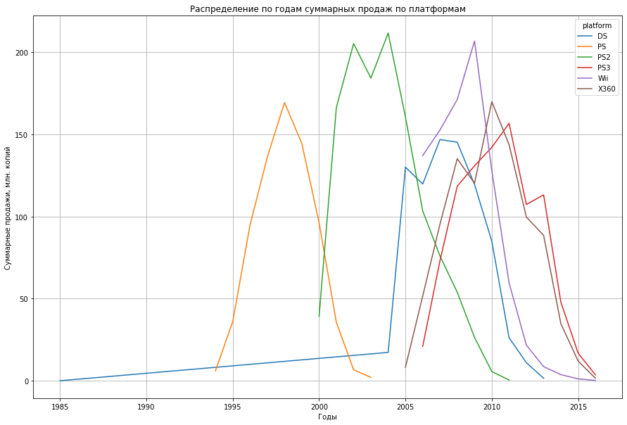

```python
# Построим график распределения
build_line_plot((games[games['platform'].isin(top_platforms)] # выберем Top-6 платформ
                    .pivot_table(values='total_sales', # посчитаем сумму по годам
                                 index=['platform','year_of_release'],
                                 aggfunc='sum')
                    .reset_index()), # развернём мультииндекс в столбцы
                'year_of_release',
                'total_sales',
                'platform',
                "Распределение по годам суммарных продаж по платформам",
                'Годы',
                'Суммарные продажи, млн. копий',
                figsize=(15, 10))
```

На графике видно, что средний срок жизни платформы (от возникновения до исчезновения) примерно равен 10 годам.

Ранее на основе анализа количества выпущенных игр мы ограничили актуальный период исследования 2002-2016 годами. С учётом среднего срока жизни платформы актуальный период можно было бы ограничить 2006-2016 годами, однако для целей прогнозорования на следующий год такой долгий период не подходит - для этого надо учитывать тренды последних лет, а популярные 10 лет назад модели вполне могли устареть.

Поэтому включим в актуальный период 2 последних полных года и текущий, возможно неполный:

```python
games_actual = games[games['year_of_release'] >= 2014].copy()
games_actual.sample(3)
```

|  | name | platform | year_of_release | genre | na_sales | eu_sales | jp_sales | other_sales | critic_score | user_score | rating | total_sales |
| --- | --- | --- | --- | --- | --- | --- | --- | --- | --- | --- | --- | --- |
| 13966 | Warriors Orochi 3 | XOne | 2014 | Action | 0.01 | 0.03 | 0.0 | 0.00 | NaN | NaN | unk | 0.04 |
| 11129 | Might & Magic Heroes VII | PC | 2015 | Strategy | 0.00 | 0.08 | 0.0 | 0.00 | NaN | NaN | unk | 0.08 |
| 7262 | Naruto Shippuden: Ultimate Ninja Storm Revolution | X360 | 2014 | Fighting | 0.14 | 0.06 | 0.0 | 0.02 | 62.0 | 7.3 | T | 0.22 |

### Изучение продаж по платформам за актуальный период

*Построим распределение суммарных продаж по платформам* за актуальный период:

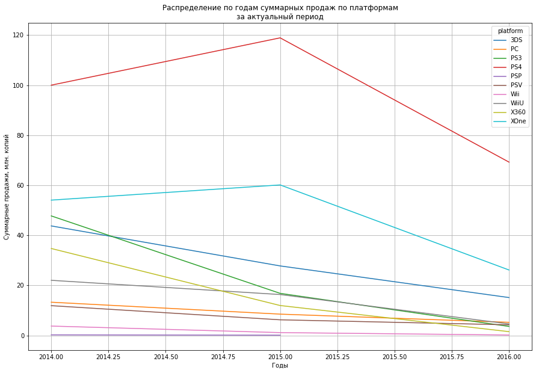

```python
# Построим график распределения
build_line_plot((games_actual # выберем данные
                    .pivot_table(values='total_sales', # посчитаем сумму по годам
                                 index=['platform','year_of_release'],
                                 aggfunc='sum')
                    .reset_index()), # развернём мультииндекс в столбцы
                'year_of_release',
                'total_sales',
                'platform',
                "Распределение по годам суммарных продаж по платформам\nза актуальный период",
                'Годы',
                'Суммарные продажи, млн. копий',
                figsize=(15, 10))
```

В актуальном периоде по продажам лидировали платформы PS4, XOne, 3DS, PS3, X360:

```python
get_top_platforms(games_actual, 2014, 2016)
```

```
platform
PS4     288.149994
XOne    140.360001
3DS      86.680000
PS3      68.180000
X360     48.220001
WiiU     42.980000
PC       27.050001
PSV      22.400000
Wii       5.070000
PSP       0.360000
Name: total_sales, dtype: float32
```

При этом, с учётом возможной неполноты данных за 2016 год, растут продажи всего по двум платформам (PS4 и XOne), по остальным - снижаются с разной степенью интенсивности.

Очевидно, **самыми перспективными на конец актуального периода следует признать платформы PS4 и XOne**.

*Построим диаграммы размаха по глобальным продажам игр в разбтвке по платформам* (платформы перечислены *в порядке уменьшения максимальных значений продаж*):

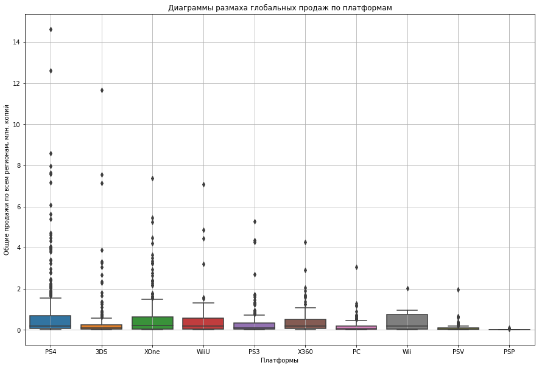

```python
build_box_plot(games_actual, "platform", "total_sales",
               title='Диаграммы размаха глобальных продаж по платформам',
               x_label='Платформы',
               y_label='Общие продажи по всем регионам, млн. копий')
```

По самой популярной платформе PS4 и занимающей третье место 3DS выбросы наблюдаются до 12 млн. проданных копий и выше. Продажи по остальным укладываются в 8 млн. копий.

Повысим информативность графика:

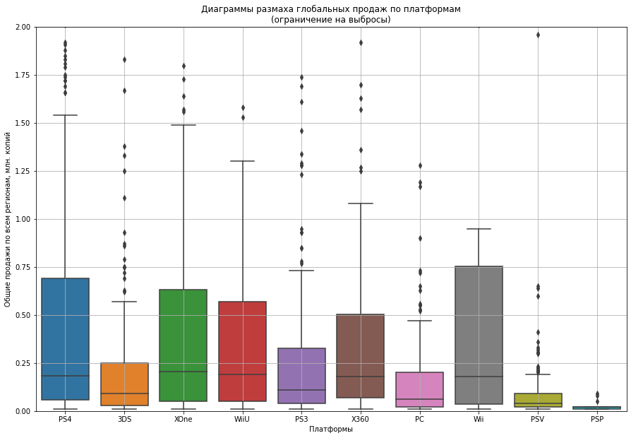

```python
build_box_plot(games_actual, "platform", "total_sales",
               title='Диаграммы размаха глобальных продаж по платформам\n(ограничение на выбросы)',
               x_label='Платформы',
               y_label='Общие продажи по всем регионам, млн. копий',
               y_lim=(0,2))
```

Все платформы, за исключением японской Sony Playstation Portable (PSP), обладают достаточно большим разбросом продаж. PSP претерпела последний [редизайн](https://ru.wikipedia.org/wiki/PlayStation_Portable#%D0%9C%D0%BE%D0%B4%D0%B5%D0%BB%D0%B8) в 2011 году. При среднем сроке жизни поколений данной платформы до 3 лет неудивительно, что популярность данной платформы в актуальный период мала.

Наибольших показателей продажи достигали на платформах PS4 и 3DS. Однако, если не учитывать статистические выбросы (по версии диаграмм) продаж отдельных игр, **наиболее популярными на всём срезе актуального периода следует признать платформы PS4 от Sony, XOne от Microsoft, а также WiiU от Nintendo**, что частично подтверждает сделанные ранее выводы на основе распределений.

**Следует отметить**, что все без исключения диаграммы размаха сильно смещены влево, что свидетельствует о том, что подавляющее большинство игр на всех платформах обладает достаточно скромными продажами, а доля "хитов" - сравнительно невелика.

*Исследуем глубже популярную платформу Sony PS4.* Выявим зависимость между оценками пользователей и критиков и продажами игр внутри платформы. Построим матрицу попарной корреляции Пирсона для этих параметров:

```python
columns = ['total_sales', 'user_score', 'critic_score']

games_actual.query("platform == 'PS4'")[columns].corr().style.background_gradient('coolwarm')
```

|  | total_sales | user_score | critic_score |
| --- | --- | --- | --- |
| total_sales | 1.000000 | -0.040132 | 0.402661 |
| user_score | -0.040132 | 1.000000 | 0.546434 |
| critic_score | 0.402661 | 0.546434 | 1.000000 |

Как видно из матрицы корреляции, оценки критиков влияют на продажи сильнее оценок пользователей. Зависимость закономерно прямая: чем выше оценка критика, тем выше продажи.

В то же время, пользователи склонны недооценивать игры на данной платформе - наблюдается обратная и достаточно слабая зависимость продаж от пользовательских оценок.

**Любопытно отметить**, что существует довольно сильная прямая зависимость между оценками критиков и пользователей. В этой ситуации при оценке перспектив конкретной игры целесообразнее онриентироваться на оценку критиков, как сильнее влияющую на продажи.

*Построим диаграммы рассеяния для зависимости продаж от двух видов оценок*:

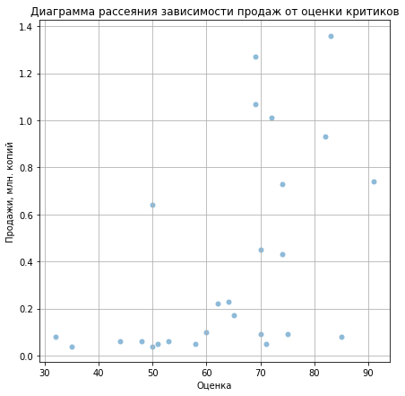

```python
# диаграмма зависимости продаж от оценок критиков
build_scatter_plot(games_actual.query("platform == 'X360'"),
                   "critic_score", "total_sales",
                   title='Диаграмма рассеяния зависимости продаж от оценки критиков',
                   x_label='Оценка', y_label='Продажи, млн. копий',
                   alpha=.5, ax=None)
```

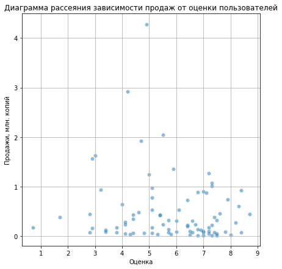

```python
# диаграмма зависимости продаж от оценок пользователей
build_scatter_plot(games_actual.query("platform == 'X360'"),
                   "user_score", "total_sales",
                   title='Диаграмма рассеяния зависимости продаж от оценки пользователей',
                   x_label='Оценка', y_label='Продажи, млн. копий',
                   alpha=.5, ax=None)
```

*Рассмотрим продажи на платформах, отличных от Sony PS4.* Построим матрицу корреляции:

```python
columns = ['total_sales', 'user_score', 'critic_score']

games_actual.query("platform != 'PS4'")[columns].corr().style.background_gradient('coolwarm')
```

|  | total_sales | user_score | critic_score |
| --- | --- | --- | --- |
| total_sales | 1.000000 | -0.023478 | 0.309474 |
| user_score | -0.023478 | 1.000000 | 0.485783 |
| critic_score | 0.309474 | 0.485783 | 1.000000 |

И диаграммы рассеяния:

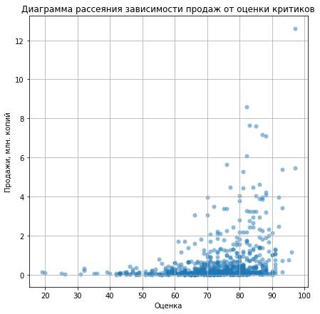

```python
# диаграмма зависимости продаж от оценок критиков
build_scatter_plot(games_actual.query("platform != 'X360'"),
                   "critic_score", "total_sales",
                   title='Диаграмма рассеяния зависимости продаж от оценки критиков',
                   x_label='Оценка', y_label='Продажи, млн. копий',
                   alpha=.5, ax=None)
```

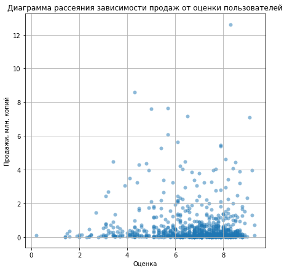

```python
# диаграмма зависимости продаж от оценок пользователей
build_scatter_plot(games_actual.query("platform != 'X360'"),
                   "user_score", "total_sales",
                   title='Диаграмма рассеяния зависимости продаж от оценки пользователей',
                   x_label='Оценка', y_label='Продажи, млн. копий',
                   alpha=.5, ax=None)
```

Анализируя матрицы корреляции и диаграммы рассеяния, можно сделать вывод, что на других платформах исследуемые зависимости слабее, по сравнению с лидером - PS4, но тенденции сохраняются.

### Изучение продаж по жанрам

*Рассмотрим распределение суммарных продаж игр по жанрам* за актуальный период:

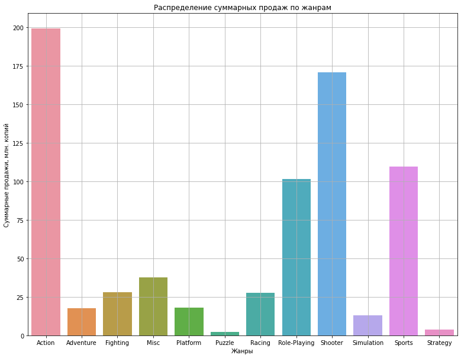

```python
build_bar_plot(df=(games_actual # выберем данные
                   .pivot_table(values='total_sales', # посчитаем сумму по годам
                                index=['genre'],
                                aggfunc='sum')
                   .reset_index()),
               x_col='genre',
               y_col='total_sales',
               title='Распределение суммарных продаж по жанрам',
               x_label='Жанры',
               y_label='Суммарные продажи, млн. копий', figsize=(13, 10))
```

Как следует из диаграммы распределения, игры разных жанров продаются не одинаково:

- из 12 представленных жанров лидируют 4 - Action, Shooter, Sports, Role-Playing;
- в средней нише 5 жанров - Fighting, Racing, Platform, Adventure, Simulation;
- замыкают список Strategy и Puzzle.

**Замечание**: Жанр "разное" - Misc - не рассматриваем, т.к. в него попадает смесь различных непопулярных жанров.

*Лидерами продаж* являются игры в жанре Action (около 200 млн. проданных копий за актуальный период). За ними следуют "стрелялки" и спортивные игры (около 170 и 110 млн. копий соответственно).

*В аутсайдерах* - стратегии и головоломки (5 и менее млн. копий на каждый жанр за актуальный период.).

В то же время, общие продажи - не мсамая хорошая метрика для оценки прибыльности жанра, поскольку редкие "хиты" могут существенно перебивать по продажам множество "середняков" жанра.

Для оценки медианных продаж по каждому жанру, построим диаграммы размаха:

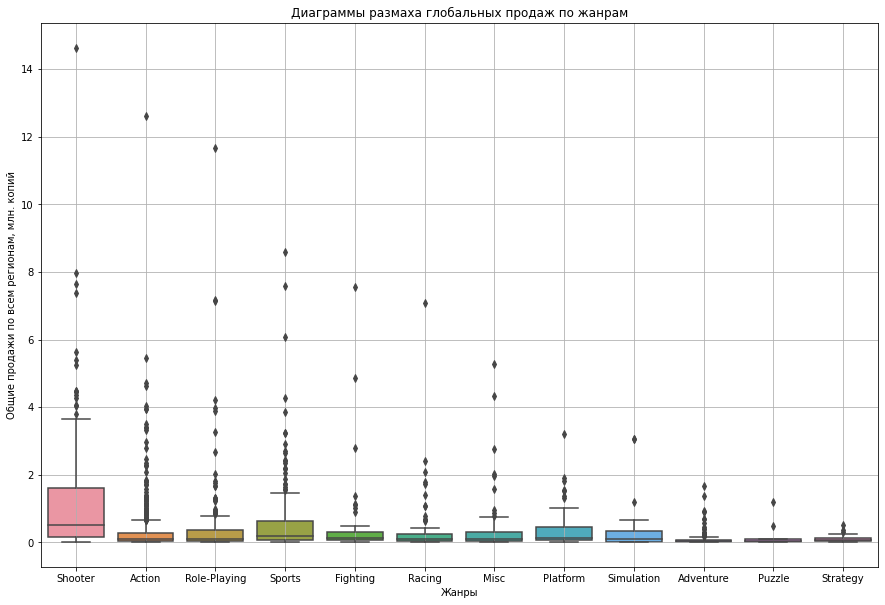

```python
build_box_plot(games_actual, "genre", "total_sales",
               title='Диаграммы размаха глобальных продаж по жанрам',
               x_label='Жанры',
               y_label='Общие продажи по всем регионам, млн. копий')
```

Итак, "стрелялки" переместились на 1 место, а прежний лидер - Action - набирал свои продажи исключительно за счёт большего количества "хитов" в этом жанре.

Настроим диаграмму:

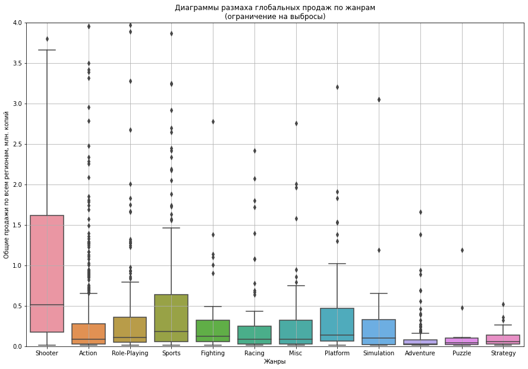

```python
build_box_plot(games_actual, "genre", "total_sales",
               title='Диаграммы размаха глобальных продаж по жанрам\n(ограничение на выбросы)',
               x_label='Жанры',
               y_label='Общие продажи по всем регионам, млн. копий',
               y_lim=(0,4))
```

Полученная диаграмма наглядно иллюстрирует, что по медианным продажам лидируют "стрелялки", за ними следуют спортивные игры и платформеры.

### Выводы

1. В ходе EDA мы:
   - выбрали актуальный период для исследования;
   - изучили продажи по годам в разрезе игровых платформ;
   - изучили продажи по жанрам.
1. На основании изучения времени жизни платформ мы ограничили актуальный период 2014-2016 годами.
1. Самыми перспективными на конец актуального периода, наиболее близкий к прогнозируемому году, следует признать платформы PS4 и XOne.
1. Оценки критиков влияют на продажи сильнее оценок пользователей. Зависимость продаж от мнения критиков - прямая: чем выше оценка, тем выше продажи. Кроме того, существует довольно сильная прямая зависимость между оценками критиков и пользователей. В этой ситуации при оценке перспектив конкретной игры целесообразнее онриентироваться на оценку критиков, как сильнее влияющую на продажи. Кроме того, отмечено, что пользователи склонны недооценивать игры на данной платформе - наблюдается обратная и достаточно слабая зависимость продаж от пользовательских оценок.
1. Тенденции зависимомти продаж от оценок критиков и пользователей для лидирующей платформы и остальных сохраняются.
1. Лидерами продаж являются игры в жанре Action (около 200 млн. проданных копий за актуальный период). За ними следуют "стрелялки" и спортивные игры (около 170 и 110 млн. копий соответственно). В аутсайдерах - стратегии и головоломки (5 и менее млн. копий на каждый жанр за актуальный период.).
1. В то же время, общие продажи - не мсамая хорошая метрика для оценки прибыльности жанра, поскольку редкие "хиты" могут существенно перебивать по продажам множество "середняков" жанра. Построенные диаграммы размаха наглядно иллюстрируют, что по медианным продажам лидируют "стрелялки", за ними следуют спортивные игры и платформеры.

## Портрет типичного пользователя каждого региона

В данных выделены 3 региона продаж:

- NA - Северная Америка;
- EU - Европа;
- JP - Япония.

Опишем "портрет" типичного пользователя каждого выделенного региона:

- наиболее и наименее популярные игровые платформы;
- наиболее и наименее популярные жанры;
- зависимость продаж от рейтинга ESRB.

Рейтинг ESRB включает в себя следующие категории:

- «EC» («Early childhood») — «Для детей младшего возраста»;
- «E» («Everyone») — «Для всех»;
- «E10+» («Everyone 10 and older») — «Для всех от 10 лет и старше»;
- «T» («Teen») — «Подросткам»;
- «M» («Mature») — «Для взрослых»;
- «AO» («Adults Only 18+») — «Только для взрослых»;
- «RP» («Rating Pending») — «Рейтинг ожидается».

### Портрет типичного пользователя региона NA

Сформируем профиль пользователей региона NA:

```
Top-5 платформ в NA: ['PS4', 'XOne', 'X360', '3DS', 'PS3']
```

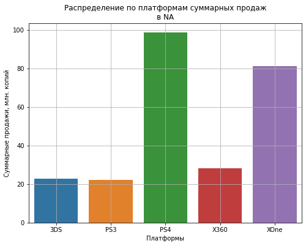

```
Top-5 жанров в NA: ['Shooter', 'Action', 'Sports', 'Role-Playing', 'Misc']
```

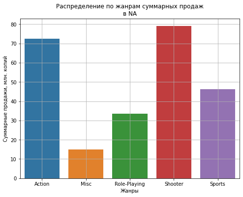

```
ESRB рейтинги в NA: ['E', 'E10+', 'M', 'T', 'unk']
```

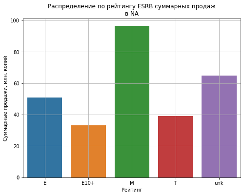

```python
make_region_profile(games_actual, 'na_sales', 'NA')
```

Опишем распределение суммарных продаж в регионе NA для Top-5 платформ за актуальный период:

**Список Top-5 платформ в регионе NA** выглядит следующим образом: PS4, XOne, X360, 3DS, PS3.

**Наиболее популярной платформой** за актуальный период в Северной Америке является PS4, наименее популярной - PS3.

За исключением двух лидеров (PS4, XOne), список Top-5 характеризуется продажами практически на одном уровне - 20-30 млн. копий.

Рассмотрим жанровые предпочтения пользователей в Северной Америке:

**Список Top-5 жанров в регионе NA** выглядит следующим образом: Shooter, Action, Sports, Role-Playing, Misc.

**Наиболее популярными жанрами** за актуальный период в Северной Америке являются Shooter и Action, наименее популярным - Role-Playing.

Крепким "середняком" в Северной америке выглядит жанр Sports.

В группу "разное" (Misc) входит достаточно большое количество игр "узких", новых жанров, что может свидетельствовать об инновационности игровой индустрии региона.

Рассмотрим влияние рейтинга на продажи в NA:

В Cеверной Америке продажи по рейтингу распределились следующим образом:

- лидируют игры "для взрослых" (около 95 млн. копий),
- игры "для всех" (около 50 млн. копий),
- игры "для подростков" (около 40 млн. копий),
- игры "для всех от 10 лет и старше" (около 32 млн. копий).

*Следует отметить*, что ESRB - североамериканский рейтинг, и есть вероятность (однако нет полной уверенности), что что достаточно большое количество игр, помеченных нами на этапе предобработки, как "unk", на самом деле могут быть поданными на присвоение рейтинга и, таким образом, иметь рейтинг RP.

### Портрет типичного пользователя региона EU

Сформируем профиль пользователей региона EU:

```
Top-5 платформ в EU: ['PS4', 'XOne', 'PS3', 'PC', '3DS']
```

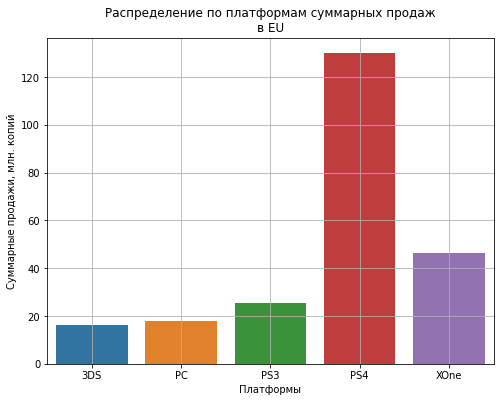

```
Top-5 жанров в EU: ['Action', 'Shooter', 'Sports', 'Role-Playing', 'Racing']
```

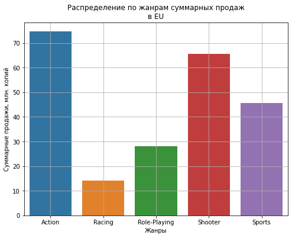

```
ESRB рейтинги в EU: ['E', 'E10+', 'M', 'T', 'unk']
```

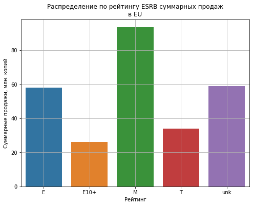

```python
make_region_profile(games_actual, 'eu_sales', 'EU')
```

Опишем распределение суммарных продаж в регионе EU для Top-5 платформ за актуальный период:

**Список Top-5 платформ в регионе EU** выглядит следующим образом: PS4, XOne, PS3, PC, 3DS.

**Наиболее популярной платформой** за актуальный период в Европе является PS4, наименее популярными - PC и 3DS.

Распределение продаж по платформам в Европейском регионе выглядит следующим образом:

Рассмотрим жанровые предпочтения пользователей в Европе:

**Список Top-5 жанров в регионе EU** выглядит очень похоже на регион NA: Action, Shooter, Sports, Role-Playing, Racing.

**Наиболее популярными жанраим** за актуальный период в Европе являются Action и Shooter (ситуация похожа на Северную Америку "наоборот"), аутсайдер поменялся - вместо ролевых игр Top-5 замыкают гонки.

В остальном Европейский регион по жанровым предпочтениям похож на Северную Америку, возможно потому, что большая часть игр, продаваемых в Европе, выпущена в Америке. При этом на европейском рынке отмечается отсутствие группы "разное", что также подтверждает этот вывод.

Рассмотрим влияние рейтинга на продажи в EU:

В Европе продажи по рейтингу распределились следующим образом:

- лидируют игры "для взрослых" (свыше 90 млн. копий),
- игры "для всех" (около 60 млн. копий),
- игры "для подростков" (около 33 млн. копий),
- игры "для всех от 10 лет и старше" (свыше 25 млн. копий).

Так же как и в Америке, в европе наблюдается достаточно большое количество игр с рейтингом unknown.

Как видим, ситуация с зависимостью продаж от рейтинга напоминает Северную Америку "в миниатюре". Что также подтверждает тезис о том, что большая часть игр, продаваемых в Европе, выпущена в Америке.

### Портрет типичного пользователя региона JP

Сформируем профиль пользователей региона JP:

```
Top-5 платформ в JP: ['3DS', 'PS4', 'PSV', 'PS3', 'WiiU']
```

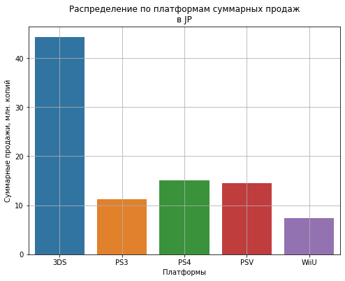

```
Top-5 жанров в JP: ['Role-Playing', 'Action', 'Fighting', 'Misc', 'Shooter']
```

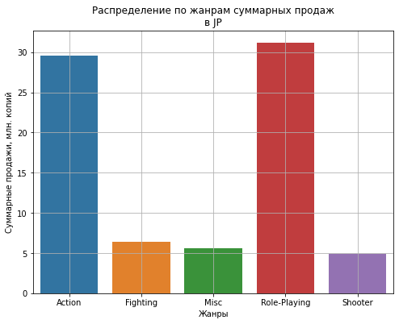

```
ESRB рейтинги в JP: ['E', 'E10+', 'M', 'T', 'unk']
```

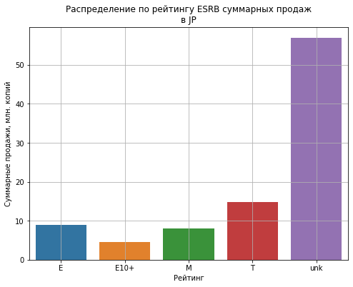

```python
make_region_profile(games_actual, 'jp_sales', 'JP')
```

Опишем распределение суммарных продаж в регионе JP для Top-5 платформ за актуальный период:

**Список Top-5 платформ в регионе JP** выглядит следующим образом: 3DS, PS4, PSV, PS3, WiiU.

Здесь уже нет платформ американских компаний - только японские: 3DS, WiiU - Nintendo; PS4, PSV, PS3 - Sony.

На удивление, лидирующая в мире PS4 пользуется достаточно скромной популярностью на родине производителя, уступая 3DS от Nintendo.

**Наиболее популярной платформой** за актуальный период в Японии является 3DS, наименее популярной - WiiU. Консоли от Sony держатся в группе "середняков".

Распределение продаж по платформам в Японии выглядит следующим образом:

Рассмотрим жанровые предпочтения пользователей в Японии:

**Список Top-5 жанров в регионе JP** выглядит совсем не похоже на регион NA: Role-Playing, Action, Fighting, Misc, Shooter.

**Наиболее популярным жанром** за актуальный период в Японии являются ролевые игры, наименее популярным - лидирующие в Америке "стрелялки".

Несмотря на то, что Япония по жанровым предпочтениям совершенно не похожа на NA или EU, нельзя не отметить, что, аналогично американской игровой индустрии, японская также является в достаточной степени инновационной, о чём свидетельствуют достаточно большие продажи игр мелких жанров, объединённых в "другое" (Misc).

Рассмотрим влияние рейтинга на продажи в JP:

В Японии продажи по рейтингу распределились следующим образом:

- лидируют игры без рейтинга - unk (порядка 60 млн. копий),
- игры "для подростков" (около 15 млн. копий),
- игры "для всех" (около 9 млн. копий),
- игры "для взрослых" (около 8 млн. копий),
- игры "для всех от 10 лет и старше" (около 5 млн. копий).

Подобная ситуация сложилась, скорее всего из-за того, что японская игровая индустрия ориентирована, в первую очередь, на внутренний рынок, а игровых рейтингов в Стране восходящего солнца не существует.

### Выводы

1. Мы опимали портрет типичного пользователя для 3 регионов продаж:
   - NA - Северная Америка;
   - EU - Европа;
   - JP - Япония.
1. Наиболее популярные игровые платформы распределились следующим образом:
   - в регионе NA - PS4, XOne, X360, 3DS, PS3;
   - в регионе EU - PS4, XOne, PS3, PC, 3DS;
   - в регионе JP - 3DS, PS4, PSV, PS3, WiiU.

Как видим, в Америке Европе лидирующую американскую платформу потеснила по популярности новая японская PS4, в то время, как в Японии, ориентированной на потребление собственной продукции, лидирует платформа 3DS от Nintendo.

1. Наиболее популярные игровые жанры распределились следующим образом:
   - в регионе NA - Shooter, Action, Sports, Role-Playing, Misc;
   - в регионе EU - Action, Shooter, Sports, Role-Playing, Racing;
   - в регионе JP - Role-Playing, Action, Fighting, Misc, Shooter.

Как видим, европейские и американские жанровые предпочтения похожи, за исключением аутсайдеров, японские же - в корне отличаются.

1. Зависимость продаж от рейтинга ESRB в Америке и Европе похожа, что можно объяснить тем, что большая часть игр, продаваемых в Европе, выпущена в Америке. Япония в меньшей степени зависит от рейтинга, ориентируясь, как мы уже говорили, на внутренний рынок, на котором не существует игровых рейтингов.

## Проверка статистических гипотез

В рамках исследования необходимо проверить 2 гипотезы:

1. Средние пользовательские рейтинги платформ Xbox One и PC одинаковые.
2. Средние пользовательские рейтинги жанров Action и Sports разные.

### Проверка гипотезы №1

Необходимо проверить гипотезу "Средние пользовательские рейтинги платформ Xbox One и PC одинаковые".

Сформулируем соответствующие статистические гипотезы:

- H0 - средняя пользовательская оценка для платформы XOne равна средней пользовательской оценке для платформы PC.
- H1 - средняя пользовательская оценка для платформы XOne НЕ равна средней пользовательской оценке для платформы PC.

Это статистическая гипотеза о равенстве средних двух генеральных совокупностей. Посчитаем размеры выборок:

```python
print('Длина выборки для XOne:',
      len(games_actual.query('platform == "XOne"')))
print('Доля пропусков оценок для XOne:',
      (games_actual.query('platform == "XOne"')['user_score']
       .isna().sum()) / len(games_actual.query('platform == "XOne"')))

print('\nДлина выборки для PC:',
      len(games_actual.query('platform == "PC"')))
print('Доля пропусков оценок для PC:',
      (games_actual.query('platform == "PC"')['user_score']
       .isna().sum()) / len(games_actual.query('platform == "PC"')))
```

```
Длина выборки для XOne: 228
Доля пропусков оценок для XOne: 0.27631578947368424

Длина выборки для PC: 151
Доля пропусков оценок для PC: 0.19205298013245034
```

Итак, мы имеем выборки размером 228 и 151 испытание, в которых 27.6% и 19.2% пропусков соответственно. Мы не имеем механизма восстановления пропущенных оценок, а для выполнения статистических критериев пропуски в выборках недопустимы.

В этих условиях для проверки 1 гипотезы не будем учитывать пропуски в выборках (используем параметр `nan_policy='omit'`), зададим уровень значимости критерия и используем параметр `equal_var=False`:

```python
# зададим пороговое значение
alpha = .05 # если p-value окажется меньше него - отвергнем гипотезу

# выполним статистический тест на равенство средних
# двух генеральных совокупностей
results = st.ttest_ind(
    games_actual.query('platform == "XOne"')['user_score'],
    games_actual.query('platform == "PC"')['user_score'],
    nan_policy='omit',
    equal_var=False
)

print('статистика разности:', results.statistic)
print('p-значение:', results.pvalue)

if results.pvalue < alpha:
    print("Отвергаем H0")
else:
    print("Не получилось отвергнуть H0")
```

```
статистика разности: 1.5777614590984412
p-значение: 0.11601379428432244
Не получилось отвергнуть H0
```

На имеющихся данных на 5% уровне значимости не имеется оснований отвергнуть гипотезу H0 в пользу альтернативы H1. Средние пользовательские рейтинги платформ Xbox One и PC статистически одинаковы.

### Проверка гипотезы №2

Необходимо проверить гипотезу "Средние пользовательские рейтинги жанров Action и Sports разные".

Сформулируем соответствующие статистические гипотезы:

- H0 - средняя пользовательская оценка для жанра Action равна средней пользовательской оценке для жанра Sports.
- H1 - средняя пользовательская оценка для жанра Action НЕ равна средней пользовательской оценке для жанра Sports.

Это статистическая гипотеза о равенстве средних двух генеральных совокупностей. Посчитаем размеры выборок:

```python
print('Длина выборки для Action:',
      len(games_actual.query('genre == "Action"')))
print('Доля пропусков оценок для Action:',
      (games_actual.query('genre == "Action"')['user_score']
       .isna().sum()) / len(games_actual.query('genre == "Action"')))

print('\nДлина выборки для Sports:',
      len(games_actual.query('genre == "Sports"')))
print('Доля пропусков оценок для Sports:',
      (games_actual.query('genre == "Sports"')['user_score']
       .isna().sum()) / len(games_actual.query('genre == "Sports"')))
```

```
Длина выборки для Action: 619
Доля пропусков оценок для Action: 0.5201938610662359

Длина выборки для Sports: 161
Доля пропусков оценок для Sports: 0.2111801242236025
```

Итак, мы имеем выборки размером 619 и 161 испытаний, в которых 52% и 21.1% пропусков соответственно. Мы не имеем механизма восстановления пропущенных оценок, а для выполнения статистических критериев пропуски в выборках недопустимы.

В этих условиях для проверки 2 гипотезы не будем учитывать пропуски в выборках (используем параметр `nan_policy='omit'`), зададим уровень значимости критерия и используем параметр `equal_var=False`:

```python
# зададим пороговое значение
alpha = .05 # если p-value окажется меньше него - отвергнем гипотезу

# выполним статистический тест на равенство средних
# двух генеральных совокупностей
results = st.ttest_ind(
    games_actual.query('genre == "Action"')['user_score'],
    games_actual.query('genre == "Sports"')['user_score'],
    nan_policy='omit',
    equal_var=False
)

print('статистика разности:', results.statistic)
print('p-значение:', results.pvalue)

if results.pvalue < alpha:
    print("Отвергаем H0")
else:
    print("Не получилось отвергнуть H0")
```

```
статистика разности: 8.384611346319303
p-значение: 1.1825796838209195e-14
Отвергаем H0
```

На имеющихся данных на 5% уровне значимости имеются основания отвергнуть гипотезу H0 в пользу альтернативы H1. Средние пользовательские рейтинги жанров Action и Sports различаются.

### Выводы

1. Мы проверили две статистические гипотезы:
   - о равенстве средних пользовательских оценок для платформ XOne и PC;
   - o равенстве средних пользовательских оценок для жанров Action и Sports.
1. На имеющихся данных на 5% уровне значимости только вторая статистическая гипотеза была отвергнута в пользу двусторонней альтернативы.
1. Таким образом, результаты проверки статистических гипотез:
   - подтверждают изначальную гипотезу "Средние пользовательские рейтинги платформ Xbox One и PC одинаковые";
   - подтверждают изначальную гипотезу "Средние пользовательские рейтинги жанров Action и Sports разные".

## Общий вывод

Проведённое исследование включает в себя:

- обзор данных;
- предварительную обработку и обогащение данных;
- исследовательский анализ данных:
  - выбор актуального периода для исследования;
  - изучение продаж в разрезе игровых платформ;
  - изучение продаж в разрезе игровых жанров;
- описание портретов типичных потребителей продукции игровой индустрии в регионах Северная Америка, Европа и Япония;
- проверку статистических гипотез.

Основные выводы по каждому этапу приведены в соответствующем разделе.